# INFO 478 Final: Exploratory Report

Andrey Butenko, Briana Lincoln, Shivank Mistry, Peach Saengcharoentrakul

5/18/2020

## Distribution of Positive COVID-19 Testing Rates

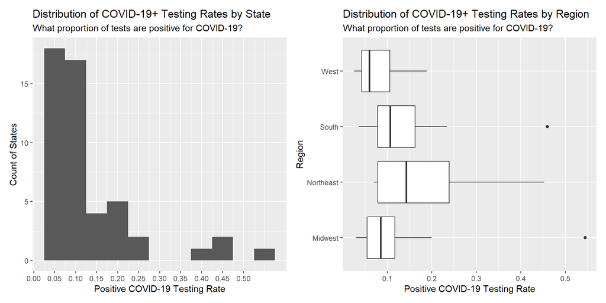

### Positive COVID-19 Testing Rates by State

| Measure | Value |
| --- | --- |
| Minimum | 0.0259814 |
| Lower Quartile | 0.0597063 |
| Median | 0.0918429 |
| Upper Quartile | 0.1455819 |
| Maximum | 0.5446435 |

### Analysis

These three visualizations assess the distribution of positive COVID-19 testing rates. In other words, these visualizations show what proportion of COVID-19 tests have positive results in a way that enables us to compare this rate across states and across regions.

The distribution of COVID-19-positive testing rates by state is positively skewed. The majority of states have low rates of COVID-19-positive tests.

This is evident in the visualizations, but also in the table summary. The median positive testing rate is 9.2%, so half of U.S. states have a positive testing rate of less than 9.2%. The upper quartile positive testing rate is 14.6%, so three-quarters of U.S. states have a positive testing rate of less than 14.6%. The most extreme example of this positive skew are naturally-isolated states like Hawaii and Alaska where less than 2.9% of tests are positive.

However, the maximum testing rate is 55%. The most extreme examples of this are are New York, New Jersey, Oklahoma, and Michigan which have 40%-55% positive testing rates.

A limitation of assessing this metric is that it reflects testing strategy as well as COVID-19 prevalance. A state with a high positive testing rate could reflect one of two scenarios. First, that state could have a low COVID-19 prevalance, but is testing people who are pretty certain to have COVID-19. Second, that state could have a high COVID-19 prevalence, but is testing most people.

For this reason, the distribution of this metric alone is insufficient. In addition, the distribution of prevalance should be considered.

[output not shown]

## Population Ecology and COVID Tests

Knowing how COVID may affect certain demographics can allow certain interventions to be put in place that targets each demographics.

### Population Over 60

For instance, with the COVID-19 breakout occurring initially in nursing homes in Washington, it may suggest implementing appropriate infection prevention and control measures for the staff and patients can help prevent the introduction of Covid-19.

[interactive chart not shown]

COVID-19 is often mentioned to afflict the older population more than the younger ones. Observing the graph above, there seems to be no relation between the percentage of individuals over sixty in a population and the percentage of positive COVID test results, or the number of COVID deaths. This suggests the dataset we are using is likely insufficient; many epidemiological studies such as [McMichael et al. (2020)](https://www.nejm.org/doi/full/10.1056/NEJMoa2005412) seem to show otherwise.

### State density

Observing state population density and positive COVID-19 cases can also be an indicator of how density may affect the spread of COVID-19 given there is a higher chance of contact between agents.

[interactive chart not shown]

Looking at the graph above, there seems to be no relation between the density of a state and the number of tests that are performed. There also seems to be no obvious relations between the number of tests conducted and the number of positive tests. It might be the case that given the limited testing that has been done, it is difficult to truly tell how many people within the population are infected.